# Besler_Jan_AssignmentV

Jan Besler

13/02/2021

### Setup

Before starting workspace is cleared.

```r
# clear workspace
rm(list = ls())
```

# Exercise 1: Setting up a new GitHub repository

> **1.1** Register on github.com in case you have not done this already.

> **1.2** Initialize a new public repository for this assignment on GitHub.

The linked repository can be found at: https://github.com/janbesler/Assignment_V_GitHub

# Exercise 2: Getting to know the API

> **2.1** Visit the documentation website for the API provided by ticketmaster.com

> **2.2** Familiarize yourself with the features and functionalities of the Ticketmaster Discovery API. Have a particular look at rate limits.

First we look at the documentation of the Ticketmaster API (https://developer.ticketmaster.com/products-and-docs/apis/getting-started/) to get the necessary information on how the database is structured and what the “rules” are, e.g. rate limits and ToS. The rate limit shown on the page lies at 5000 calls per day as of 31/01/2021.

> **2.3** Whithin the scope of this assignment, you do not have to request your own API key. Instead retrieve a valid key from the API Explorer. This API key enables you to perform the GET requests needed throughout this assignment.

The API key is a publicly available on the API Explorer (https://developer.ticketmaster.com/api-explorer/v2/).

> **2.4** Even though this API key is not secret per se (it is publicly visible onn the API Explorer website), please comply to the common secrecy practices discussed in the lecture and the tutorial: Treat the API key as a secret token. Your API key should neither appear in the code that you are submitting nor in your public GitHub repository.

```r
source("~/Uni/Data_Science/Project_Management/Assignments_DSPM/tima_key.R")
```

The key is stored separately on a file on a local machine.

# Exercise 3: Interacting with the API - the basics

> **3.1** Load the packages needed to interact with APIs using R.

```r
# load libraries
library(maps)
library(ggplot2)
library(tidyr)
library(plyr)
library(dplyr)
library(jsonlite)
library(httr)
library(rlist)
library(knitr)
```

> **3.2** Perform a first GET request, that searches for event venues in Germany (countryCode = “DE”). Extract the content from the response object and inspect the resulting list. Describe what you can see.

In the first step the results from the first site are printed and are compiled into a data frame.

```r
res_venue <- GET(url  = "https://app.ticketmaster.com/discovery/v2/venues/",
                    query = list(apikey = tima_key,
                                 locale = "*",
                                 countryCode = "DE"))
content_venue_DE <- jsonlite::fromJSON(content(res_venue, as = "text"))
```

If we use the content function on the venue data for Germany we get a list of 19 Variables. But some of the required information is stored in a data frame itself inside the first data frame. This applies for the city-, address- and location-variable.

> **3.3** Extract the name, the city, the postalCode and address, as well as the url and the longitude and latitude of the venues to a data frame.

```r
df_venue_basic <- data.frame(
              name = content_venue_DE[["_embedded"]][["venues"]][["name"]],
              city = content_venue_DE[["_embedded"]][["venues"]][["city"]][["name"]],
              postalCode = content_venue_DE[["_embedded"]][["venues"]][["postalCode"]],
              address = content_venue_DE[["_embedded"]][["venues"]][["address"]][["line1"]],
              url = content_venue_DE[["_embedded"]][["venues"]][["url"]],
              longitude = content_venue_DE[["_embedded"]][["venues"]][["location"]][["longitude"]],
              latitude = content_venue_DE[["_embedded"]][["venues"]][["location"]][["latitude"]]
        )
glimpse(df_venue_basic)
```

```
## Rows: 20
## Columns: 7
## $ name       <chr> "Gruenspan", "Philharmonie (Großer Saal)", "Beatpol", "Mart…
## $ city       <chr> "Hamburg", "Berlin", "Dresden", "Dresden", "Dessau-Roßlau",…
## $ postalCode <chr> "22767", "10785", "01157", "01099", "06844", "80809", NA, "…
## $ address    <chr> "Grosse Freiheit 58", "Herbert-von-Karajan-Straße 1", "Altb…
## $ url        <chr> "http://www.ticketmaster.de/venue/287155", "https://www.tic…
## $ longitude  <chr> "9.958075", "13.36896", "13.67471", "13.7566", "12.24645", …
## $ latitude   <chr> "53.551885", "52.51007", "51.06498", "51.06435", "51.83364"…
```

Now the first 20 values are in the desired standard data frame format.

# Exercise 4: Interacting with the API - advanced

> **4.1** Have a closer look at the list element named page. Did your GET request from exercise 3 return all event locations in Germany? Obviously not - there are of course much more venues in Germany than those contained in this list. Your GET request only yielded the first results page containing the first 20 out of several thousands of venues.

> **4.2** Check the API documentation under the section Venue Search. How can you request the venues from the remaining results pages?

The idea is to iterate the page numbers until there are less values on a page than the size of searching.

> **4.3** Write a for loop that iterates through the results pages and performs a GET request for all venues in Germany. After each iteration, extract the seven variables name, city, postalCode, address, url, longitude, and latitude. Join the information in one large data frame.

From this point on wards only code is shown without its results, because there is an error on my API request and markdown won’t knit the document if don’t set “eval = FALSE” for those chunks. As a result it can’t process the required data frames in order to plot the maps. Yet If I don’t include this option, the code doesn’t run at all. I would be glad to hints why this does not work. My research on the problem did not help, because it only refers to a “replacement has length zero” error for which all the manual corrections work fine, but the automated process of knitting doesn’t.

```r
number_events <- content_venue_DE[[3]]$totalElements
page_size <- 100
pages_DE <- floor(number_events/page_size)
last_page <- number_events - pages_DE * page_size

# creating the data frame to fill
df_venue_advanced <- data.frame(
            name = character(number_events),
            city = character(number_events),
            postalCode = numeric(number_events),
            address = character(number_events),
            url = character(number_events),
            longitude = rep(NA, number_events),
            latitude = rep(NA, number_events)
            )

# the loop for accessing each page
for (i in 1:5){
  iterated_results_DE <- GET(url  = "https://app.ticketmaster.com/discovery/v2/venues/",
                    query = list(apikey = tima_key,
                                 locale = "*",
                                 countryCode = "DE",
                                 size = page_size,
                                 page = (i-1)  # start on page 0
                           )
                    )
# for some unknown reason the loop gives out an error for all pages, hence I capped it at 5 pages.
# for manual execution this works perfectly fine, though while knitting I always get a "error in x[[jj]][iseq] <- vjj : replacement has length zero" error

  iterated_venue_DE <- jsonlite::fromJSON(content(iterated_results_DE, as = "text"))

# start filling the database
    df_venue_advanced[((i-1)*page_size + 1):(i*page_size),1] <- iterated_venue_DE[["_embedded"]][["venues"]][["name"]]
    df_venue_advanced[((i - 1) * page_size + 1):(i * page_size),2] <- iterated_venue_DE[["_embedded"]][["venues"]][["city"]][["name"]]
    df_venue_advanced[((i - 1) * page_size + 1):(i * page_size),3] <- iterated_venue_DE[["_embedded"]][["venues"]][["postalCode"]]
    df_venue_advanced[((i - 1) * page_size + 1):(i * page_size),4] <- iterated_venue_DE[["_embedded"]][["venues"]][["address"]][["line1"]]
    df_venue_advanced[((i - 1) * page_size + 1):(i * page_size),5] <- iterated_venue_DE[["_embedded"]][["venues"]][["url"]]
      if (!is.null(iterated_venue_DE[["_embedded"]][["venues"]][["location"]][["longitude"]])){
        df_venue_advanced[((i - 1) * page_size + 1):(i * page_size),6] <- as.double(iterated_venue_DE[["_embedded"]][["venues"]][["location"]][["longitude"]])
        df_venue_advanced[((i - 1) * page_size + 1):(i * page_size),7] <- as.double(iterated_venue_DE[["_embedded"]][["venues"]][["location"]][["latitude"]])
      }

  Sys.sleep(2)
}

# repeat the process for the last page
iterated_results_DE <- GET(url  = "https://app.ticketmaster.com/discovery/v2/venues/",
                    query = list(apikey = tima_key,
                                 locale = "*",
                                 countryCode = "DE",
                                 size = page_size,
                                 page = pages_DE
                           )
                    )

  iterated_venue_DE <- jsonlite::fromJSON(content(iterated_results_DE, as = "text"))

# start filling the database
    df_venue_advanced[(pages_DE * page_size + 1):nrow(df_venue_advanced),1] <- iterated_venue_DE[["_embedded"]][["venues"]][["name"]]
    df_venue_advanced[(pages_DE * page_size + 1):nrow(df_venue_advanced),2] <- iterated_venue_DE[["_embedded"]][["venues"]][["city"]][["name"]]
    df_venue_advanced[(pages_DE * page_size + 1):nrow(df_venue_advanced),3] <- iterated_venue_DE[["_embedded"]][["venues"]][["postalCode"]]
    df_venue_advanced[(pages_DE * page_size + 1):nrow(df_venue_advanced),4] <- iterated_venue_DE[["_embedded"]][["venues"]][["address"]][["line1"]]
    df_venue_advanced[(pages_DE * page_size + 1):nrow(df_venue_advanced),5] <- iterated_venue_DE[["_embedded"]][["venues"]][["url"]]
```

> **4.4** The resulting data frame should look something like this (note that the exact number of search results may have changed since this document has been last modified):

```r
glimpse(df_venue_advanced)
```

## Exercise 5: Visualizing the extracted data

> **5.1** Below, you can find code that produces a map of Germany. Add points to the map indicating the locations of the event venues across Germany.

> **5.2** You will find that some coordinates lie way beyond the German borders and can be assumed to be faulty. Set coordinate values to NA where the value of longitude is outside the range (5.866944, 15.043611) or where the value of latitude is outside the range (47.271679, 55.0846).

```r
map_DE <- na.omit(df_venue_advanced)
map_DE <- map_DE[!(df_venue_advanced$longitude < "5.866944"),]
map_DE <- map_DE[!(df_venue_advanced$longitude > "15.043611"),]
map_DE <- map_DE[!(df_venue_advanced$latitude < "47.271679"),]
map_DE <- map_DE[!(df_venue_advanced$latitude > "55.0846"),]

ger_venue <- ggplot() +
  geom_polygon(
  aes(x = long, y = lat, group = group), data = map_data("world", region = "Germany"),
  fill = "grey90",color = "black") +
  theme_void() + coord_quickmap() +
  labs(title = "Event locations across Germany", caption = "Source: ticketmaster.com") +
  theme(title = element_text(size=8, face='bold'),
  plot.caption = element_text(face = "italic")) +
  geom_point(data = map_DE, aes(x = longitude, y = latitude), na.rm = TRUE)
```

show the map:

```r
# the knitting is interrupted if I do not include the "eval = FALSE" option, executing it manually though produces a graph.
ger_venue
```

Since the map can’t be shown the normal way, I took a screenshot while doing the steps manually.

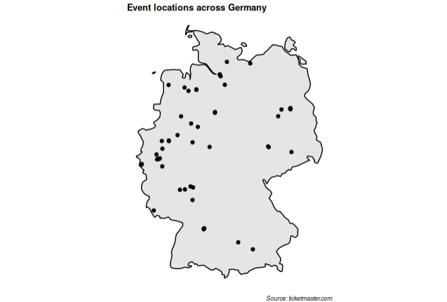

# Exercise 6: Event locations in other countries

> **6.1** Repeat exercises 2 to 5 for another European country of your choice.

first country on the list is Belgium

```r
# getting the Belgium specific data
content_venue_BE <- GET(url  = "https://app.ticketmaster.com/discovery/v2/venues/",
                    query = list(apikey = tima_key,
                                 locale = "*",
                                 countryCode = "BE"
                           )
                    )

content_venue_BE <- jsonlite::fromJSON(content(content_venue_BE, as = "text"))

# keep the same setup as previously
number_events <- content_venue_BE[[3]]$totalElements
page_size <- 100
pages <- floor(number_events/page_size)
last_page <- number_events - pages * page_size

# creating the data frame to fill
df_venue_advanced <- data.frame(
            name = character(number_events),
            city = character(number_events),
            postalCode = numeric(number_events),
            address = character(number_events),
            url = character(number_events),
            longitude = rep(NA, number_events),
            latitude = rep(NA, number_events)
            )

# the loop for accessing each page
for (i in 2:5){
  iterated_results_BE <- GET(url  = "https://app.ticketmaster.com/discovery/v2/venues/",
                    query = list(apikey = tima_key,
                                 locale = "*",
                                 countryCode = "BE",
                                 size = page_size,
                                 page = (i-1)
                           )
                    )
# same problem as with Germany, hence it is capped at 5 iterations.
  iterated_venue_BE <- jsonlite::fromJSON(content(iterated_results_BE, as = "text"))

# start filling the database
    df_venue_advanced[((i - 1) * page_size + 1):(i * page_size),1] <- iterated_venue_BE[["_embedded"]][["venues"]][["name"]]
    df_venue_advanced[((i - 1) * page_size + 1):(i * page_size),2] <- iterated_venue_BE[["_embedded"]][["venues"]][["city"]][["name"]]
    df_venue_advanced[((i - 1) * page_size + 1):(i * page_size),3] <- iterated_venue_BE[["_embedded"]][["venues"]][["postalCode"]]
    df_venue_advanced[((i - 1) * page_size + 1):(i * page_size),4] <- iterated_venue_BE[["_embedded"]][["venues"]][["address"]][["line1"]]
    df_venue_advanced[((i - 1) * page_size + 1):(i * page_size),5] <- iterated_venue_BE[["_embedded"]][["venues"]][["url"]]
      if (!is.null(iterated_venue_BE[["_embedded"]][["venues"]][["location"]][["longitude"]])){
        df_venue_advanced[((i - 1) * page_size + 1):(i * page_size),6] <- as.double(iterated_venue_BE[["_embedded"]][["venues"]][["location"]][["longitude"]])
        df_venue_advanced[((i - 1) * page_size + 1):(i * page_size),7] <- as.double(iterated_venue_BE[["_embedded"]][["venues"]][["location"]][["latitude"]])
      }

  Sys.sleep(2)
}

# repeat the process for the last page
iterated_results_BE <- GET(url  = "https://app.ticketmaster.com/discovery/v2/venues/",
                    query = list(apikey = tima_key,
                                 locale = "*",
                                 countryCode = "BE",
                                 size = page_size,
                                 page = pages
                           )
                    )

  iterated_venue_BE <- jsonlite::fromJSON(content(iterated_results_BE, as = "text"))

# start filling the database
    df_venue_advanced[(pages_BE * page_size + 1):nrow(df_venue_advanced),1] <- iterated_venue_BE[["_embedded"]][["venues"]][["name"]]
    df_venue_advanced[(pages_BE * page_size + 1):nrow(df_venue_advanced),2] <- iterated_venue_BE[["_embedded"]][["venues"]][["city"]][["name"]]
    df_venue_advanced[(pages_BE * page_size + 1):nrow(df_venue_advanced),3] <- iterated_venue_BE[["_embedded"]][["venues"]][["postalCode"]]
    df_venue_advanced[(pages_BE * page_size + 1):nrow(df_venue_advanced),4] <- iterated_venue_BE[["_embedded"]][["venues"]][["address"]][["line1"]]
    df_venue_advanced[(pages_BE * page_size + 1):nrow(df_venue_advanced),5] <- iterated_venue_BE[["_embedded"]][["venues"]][["url"]]

# creating the graph
map_BE <- na.omit(df_venue_advanced)
map_BE <- map_BE[!(df_venue_advanced$longitude < "5.866944"),] #west
map_BE <- map_BE[!(df_venue_advanced$longitude > "6.23"),] #east
map_BE <- map_BE[!(df_venue_advanced$latitude < "49.3"),] #south
map_BE <- map_BE[!(df_venue_advanced$latitude > "51.2952"),] #north

bel_venue <- ggplot() +
    geom_polygon(
  aes(x = long, y = lat, group = group), data = map_data("world", region = "Belgium"),
  fill = "grey90",color = "black") +
  theme_void() + coord_quickmap() +
  labs(title = "Event locations across Belgium", caption = "Source: ticketmaster.com") +
  theme(title = element_text(size=8, face='bold'),
  plot.caption = element_text(face = "italic")) +
  geom_point(data = map_BE, aes(x = longitude, y = latitude), na.rm = TRUE)
```

show the map:

```r
# the knitting is interrupted if I do not include the "eval = FALSE" option, executing it manually though produces a graph.
bel_venue
```

Since the map can’t be shown the normal way, I took a screenshot while doing the steps manually.

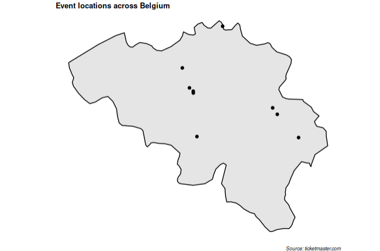

Belgium venues graphic